# 市场观察

2016/07/20

## 一、指数估值

### (一)指数动态市盈率

核心指数成分股的动态市盈率中位数走势如下图所示：

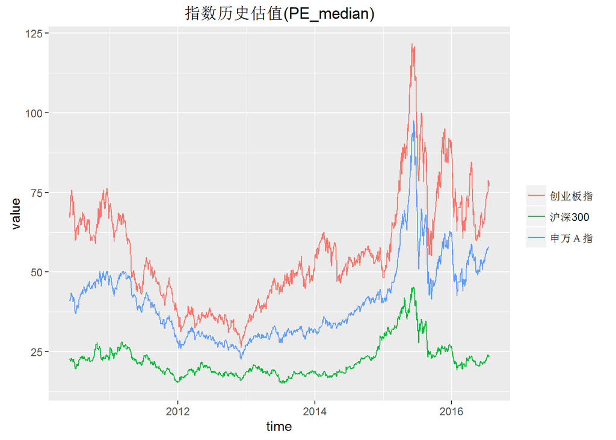

### (二)指数动态市盈率百分位

核心指数上述数据的百分位走势如下图所示：

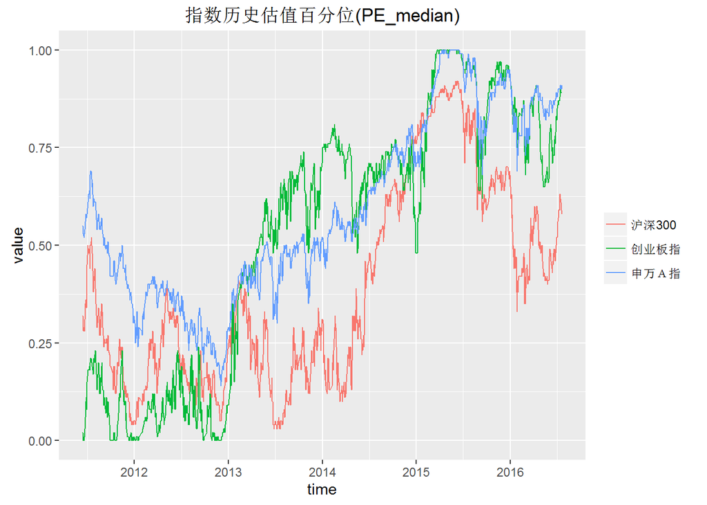

### (三)指数估值概览

纳入观察的18只指数最新的估值情况如下表：

| 日期 | 指数代码 | 指数简称 | 动态市盈率 | 上周动态市盈率 | 市盈率百分位 | 上周市盈率百分位 | 动态市净率 | 市净率百分位 |
| --- | --- | --- | --- | --- | --- | --- | --- | --- |
| 2016-07-19 | EI000979 | 大宗商品 | 50.24 | 50.12 | 0.97 | 0.97 | 2.60 | 0.52 |
| 2016-07-19 | EI000819 | 有色金属 | 68.09 | 69.79 | 0.95 | 0.96 | 4.43 | 0.90 |
| 2016-07-19 | EI801003 | 申万Ａ指 | 57.85 | 57.49 | 0.91 | 0.90 | 4.91 | 0.78 |
| 2016-07-19 | EI000805 | A股资源 | 51.70 | 50.29 | 0.89 | 0.87 | 2.60 | 0.63 |
| 2016-07-19 | EI399006 | 创业板指 | 78.18 | 75.14 | 0.89 | 0.88 | 8.62 | 0.84 |
| 2016-07-19 | EI399005 | 中小板指P | 49.15 | 49.41 | 0.86 | 0.87 | 6.10 | 0.83 |
| 2016-07-19 | EI399959 | 军工指数 | 101.91 | 100.34 | 0.86 | 0.86 | 6.82 | 0.84 |
| 2016-07-19 | EI000998 | 中证TMT | 66.35 | 60.02 | 0.85 | 0.78 | 6.41 | 0.82 |
| 2016-07-19 | EI399330 | 深证100 | 36.33 | 36.22 | 0.81 | 0.81 | 4.52 | 0.75 |
| 2016-07-19 | EI000808 | 医药生物 | 42.20 | 41.59 | 0.76 | 0.73 | 5.55 | 0.68 |
| 2016-07-19 | EI801120 | 申万食品饮料 | 46.22 | 48.13 | 0.73 | 0.76 | 4.61 | 0.62 |
| 2016-07-19 | EI000933 | 中证医药 | 40.42 | 41.14 | 0.72 | 0.76 | 4.78 | 0.49 |
| 2016-07-19 | EI000905 | 中证500 | 41.00 | 40.91 | 0.67 | 0.67 | 3.74 | 0.62 |
| 2016-07-19 | EI000300 | 沪深300 | 23.22 | 23.95 | 0.58 | 0.63 | 2.59 | 0.47 |
| 2016-07-19 | EI000827 | 中证环保 | 39.37 | 39.25 | 0.54 | 0.54 | 4.09 | 0.74 |
| 2016-07-19 | EI000932 | 中证消费 | 33.45 | 34.74 | 0.53 | 0.56 | 4.45 | 0.54 |
| 2016-07-19 | EI000934 | 中证金融 | 15.89 | 16.45 | 0.39 | 0.45 | 2.27 | 0.50 |
| 2016-07-19 | EI000016 | 上证50 | 12.12 | 12.30 | 0.10 | 0.12 | 1.53 | 0.06 |

## 二、基差

### (一)基差走势

三大股指期货隔季合约基差走势如下图：

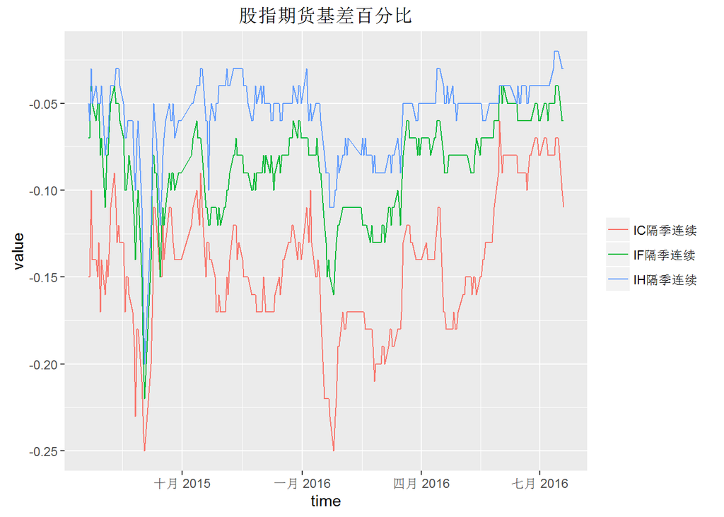

### (二)基差概况

三大股指期货连续合约基差概况如下表：

| 日期 | 合约简称 | 合约收盘价 | 基差 | 基差百分比 | 上周基差 | 上周基差百分比 |
| --- | --- | --- | --- | --- | --- | --- |
| 2016-07-19 | IH当月连续 | 2160.0 | -15.40 | -0.01 | -6.95 | 0.00 |
| 2016-07-19 | IH下月连续 | 2148.8 | -26.60 | -0.01 | -14.55 | -0.01 |
| 2016-07-19 | IH下季连续 | 2122.6 | -52.80 | -0.02 | -26.75 | -0.01 |
| 2016-07-19 | IH隔季连续 | 2105.2 | -70.20 | -0.03 | -46.75 | -0.02 |
| 2016-07-19 | IF当月连续 | 3206.0 | -42.23 | -0.01 | -10.58 | 0.00 |
| 2016-07-19 | IF下月连续 | 3176.2 | -72.03 | -0.02 | -45.18 | -0.01 |
| 2016-07-19 | IF下季连续 | 3102.4 | -145.83 | -0.04 | -79.18 | -0.02 |
| 2016-07-19 | IF隔季连续 | 3040.0 | -208.23 | -0.06 | -158.18 | -0.05 |
| 2016-07-19 | IC当月连续 | 6272.8 | -159.14 | -0.02 | -26.54 | 0.00 |
| 2016-07-19 | IC下月连续 | 6168.2 | -263.74 | -0.04 | -142.34 | -0.02 |
| 2016-07-19 | IC下季连续 | 5922.2 | -509.74 | -0.08 | -250.14 | -0.04 |
| 2016-07-19 | IC隔季连续 | 5736.0 | -695.94 | -0.11 | -505.14 | -0.08 |

## 三、套利

### (一)复牌股票套利

近两天复牌股票套利情况如下表：

[1] “无复牌股票套利”

### (二)定增基金跟踪

截止2016-07-20定增基金数据如下表，明细数据参见钱瀚的模板。

| 代码 | 名称 | 到期日期 | 最新净值 | 昨日收盘价 | 折溢价率 | 整体隐含折价率 | 大盘回撤0.1净值回撤 |
| --- | --- | --- | --- | --- | --- | --- | --- |
| 168101.OF | 九泰锐智 | 20200814 | 1.386 | 1.544 | 0.114 | 0.195 | -0.049 |
| 168102.OF | 九泰锐富 | 20210204 | 1.020 | 1.060 | 0.039 | 0.067 | -0.007 |
| 161222.OF | 国投瑞利 | 20160805 | 1.040 | 1.028 | -0.012 | 0.000 | -0.042 |
| 161225.OF | 国投瑞盈 | 20161119 | 1.029 | 1.032 | 0.003 | 0.062 | -0.074 |
| 501001.OF | 财通精选 | 20170101 | 1.108 | 1.050 | -0.052 | 0.027 | -0.092 |
| 501015.OF | 财通升级 | 20170908 | 1.023 | 1.011 | -0.012 | 0.074 | -0.018 |

定增基金近期的净值走势如下图：

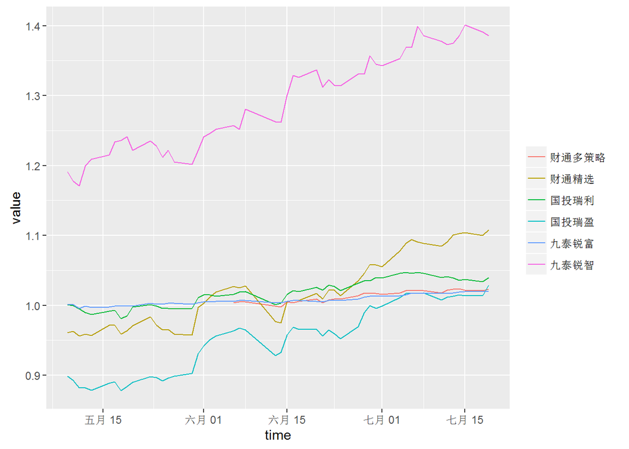

定增基金近期的折溢价走势如下图：

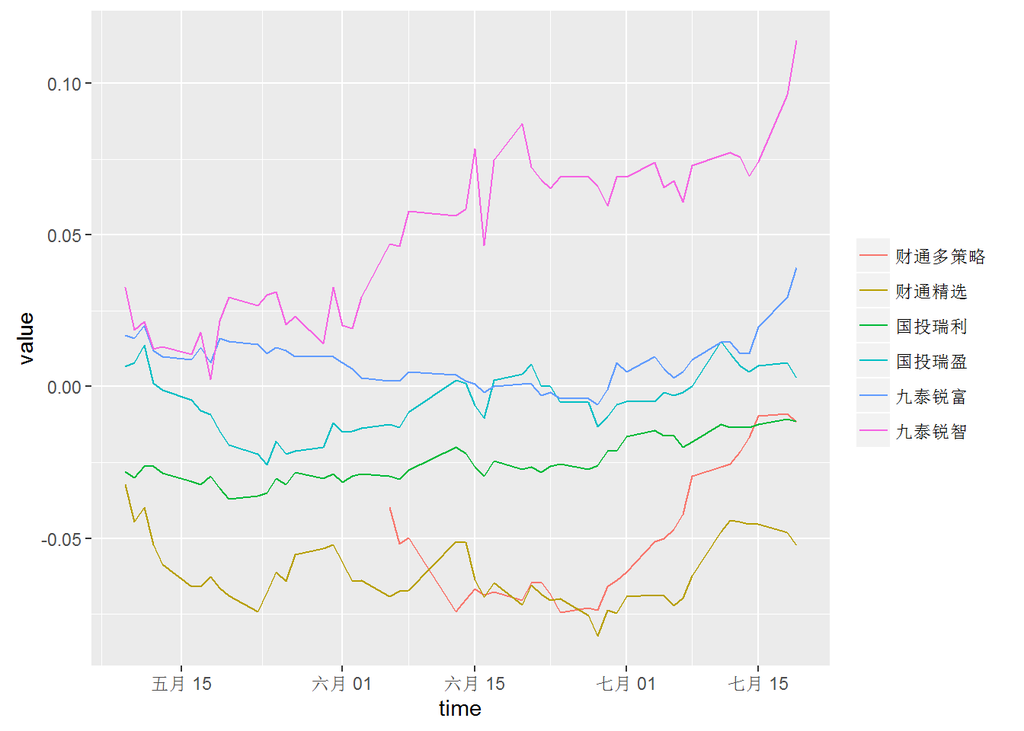

## 四、择时

### (一)大盘均线强弱指数

大盘均线强弱指数在一定程度上可以视为一个反转指标，当大盘均线得分接近8分时，预示市场接近顶部，当大盘均线得分接近0分时，预示市场接近底部。  
大盘均线强弱指数近一年来走势如下图：

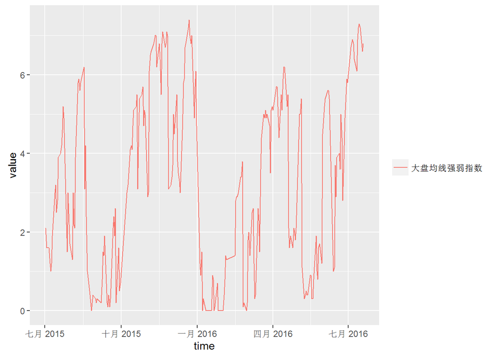

申万一级行业的最新得分及上周得分见下表：

| 日期 | 指数代码 | 指数名称 | 最新值 | 上周值 |
| --- | --- | --- | --- | --- |
| 2016-07-19 | EI801010 | 申万农林牧渔 | 8 | 8 |
| 2016-07-19 | EI801030 | 申万化工 | 8 | 8 |
| 2016-07-19 | EI801080 | 申万电子 | 8 | 6 |
| 2016-07-19 | EI801110 | 申万家用电器 | 8 | 8 |
| 2016-07-19 | EI801130 | 申万纺织服装 | 8 | 7 |
| 2016-07-19 | EI801140 | 申万轻工制造 | 8 | 7 |
| 2016-07-19 | EI801150 | 申万医药生物 | 8 | 8 |
| 2016-07-19 | EI801230 | 申万综合 | 8 | 5 |
| 2016-07-19 | EI801710 | 申万建筑材料 | 8 | 8 |
| 2016-07-19 | EI801730 | 申万电气设备 | 8 | 8 |
| 2016-07-19 | EI801750 | 申万计算机 | 8 | 7 |
| 2016-07-19 | EI801770 | 申万通信 | 8 | 8 |
| 2016-07-19 | EI801780 | 申万银行 | 8 | 8 |
| 2016-07-19 | EI801880 | 申万汽车 | 8 | 8 |
| 2016-07-19 | EI801050 | 申万有色金属 | 7 | 8 |
| 2016-07-19 | EI801200 | 申万商业贸易 | 7 | 6 |
| 2016-07-19 | EI801890 | 申万机械设备 | 7 | 7 |
| 2016-07-19 | EI801020 | 申万采掘 | 6 | 7 |
| 2016-07-19 | EI801120 | 申万食品饮料 | 6 | 8 |
| 2016-07-19 | EI801160 | 申万公用事业 | 6 | 6 |
| 2016-07-19 | EI801170 | 申万交通运输 | 6 | 6 |
| 2016-07-19 | EI801720 | 申万建筑装饰 | 6 | 7 |
| 2016-07-19 | EI801760 | 申万传媒 | 6 | 6 |
| 2016-07-19 | EI801040 | 申万钢铁 | 5 | 6 |
| 2016-07-19 | EI801740 | 申万国防军工 | 5 | 7 |
| 2016-07-19 | EI801790 | 申万非银金融 | 5 | 8 |
| 2016-07-19 | EI801210 | 申万休闲服务 | 3 | 6 |
| 2016-07-19 | EI801180 | 申万房地产 | 2 | 2 |

### (二)LLT及均线择时

LLT本质上是一个改进的单均线择时指标，较原始的均线择时延迟更低。  
择时模型和指数本身的净值走势如下图：

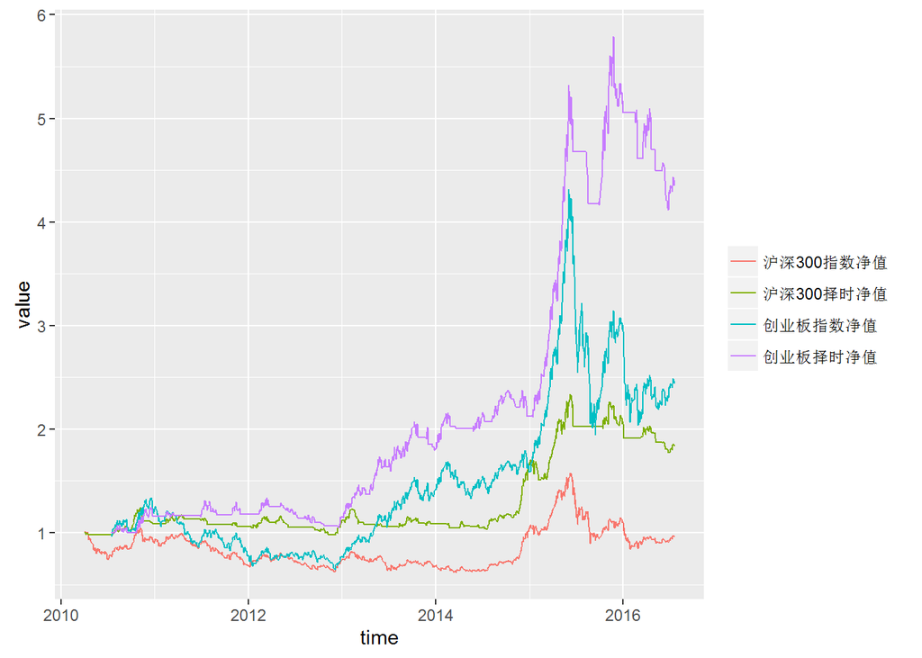

择时模型和指数的收益率统计如下表：

|  | 沪深300指 | 沪深300LLT | 创业板指 | 创业板MA |
| --- | --- | --- | --- | --- |
| 年化收益率 | -0.7 | 10.5 | 16.8 | 29.1 |
| 年化波动率 | 25.9 | 16.4 | 34.8 | 24.0 |
| 年化Sharpe值 | -2.7 | 63.9 | 48.4 | 121.3 |
| 最大回撤 | 46.7 | 24.0 | 54.9 | 28.9 |

择时模型最近10个交易日的信号如下表：

| 日期 | 沪深300收盘价 | 沪深300择时信号 | 创业板收盘价 | 创业板择时信号 |
| --- | --- | --- | --- | --- |
| 2016-07-06 | 3216.803 | hold | 2241.560 | hold |
| 2016-07-07 | 3209.954 | hold | 2233.922 | hold |
| 2016-07-08 | 3192.280 | hold | 2239.002 | hold |
| 2016-07-11 | 3203.330 | hold | 2218.588 | hold |
| 2016-07-12 | 3273.182 | hold | 2247.354 | hold |
| 2016-07-13 | 3282.868 | hold | 2285.369 | hold |
| 2016-07-14 | 3276.764 | hold | 2293.079 | hold |
| 2016-07-15 | 3276.278 | hold | 2263.784 | hold |
| 2016-07-18 | 3262.022 | hold | 2249.871 | hold |
| 2016-07-19 | 3248.234 | hold | 2273.719 | hold |

### (三)网格交易

在经历了三轮股灾，A股逐步回归正常，在过去的一段时间呈现一个震荡的格局，如果未来没有增量信息，很可能维持震荡。结合股指期货的贴水，前期研究了一下网格交易。网格交易的结果如下图：

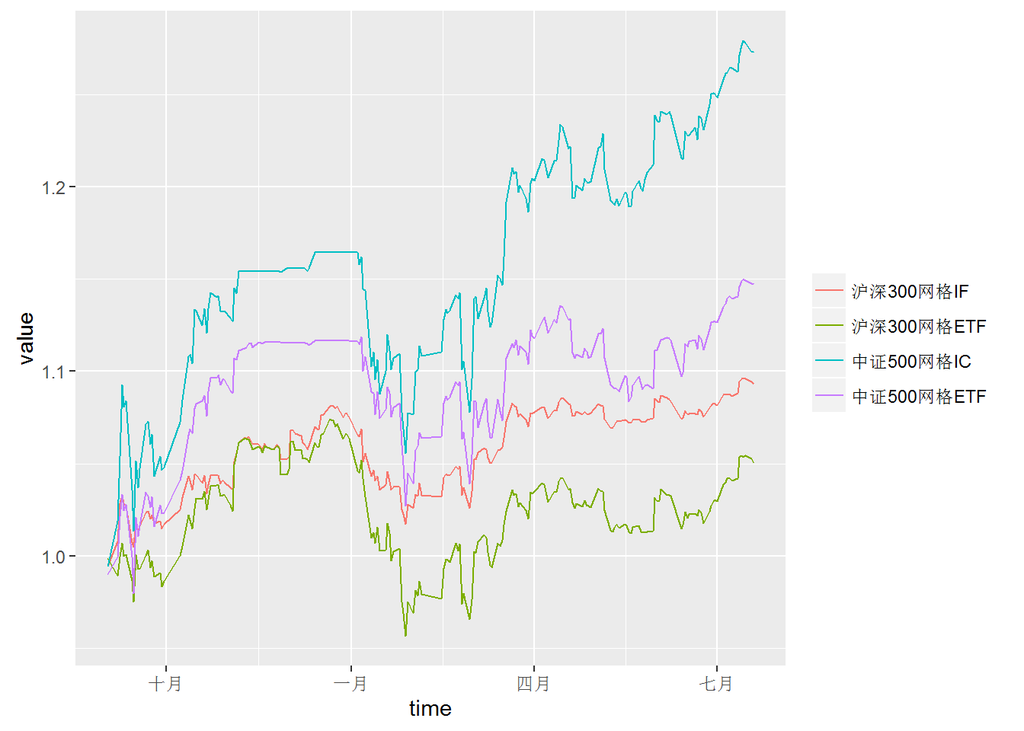

网格交易的收益统计如下表：

|  | 沪深300指数 | 沪深300网格IF | 沪深300网格ETF | 中证500指数 | 中证500网格IC | 中证500网格ETF |
| --- | --- | --- | --- | --- | --- | --- |
| 年化收益率 | -4.0 | 11.1 | 6.0 | 5.1 | 33.1 | 17.7 |
| 年化波动率 | 28.4 | 8.1 | 12.3 | 38.3 | 17.6 | 14.0 |
| 年化Sharpe值 | -14.1 | 137.3 | 48.7 | 13.2 | 187.9 | 125.8 |
| 最大回撤 | 26.4 | 5.9 | 10.9 | 33.5 | 9.4 | 8.2 |